# Streaming Stocks

Roger Qiu

2022-08-03

# The Effect of Content Released On Streaming Services

## Introduction

In this project, we analyze the effect that newly released content has on the stock of streaming companies. To do this, we look at 2 sources of data. To see if a show like Stranger Things has a noticeable effect on the stock price of Netflix. Then we see if there is a correlation between the stock prices of different streaming companies like Netflix and HBO or Disney+.

## Analysis

### The Data

First let’s loud our libraries, we’ll use the tidyverse library for most of our tools and dplyr for data manipulation. Then we load the quantmod library which will let us access historical stock prices for our streaming companies. The graph below will show the prices for each company over the last 10 years.

```r
library(tidyverse)
library(dplyr)
library(quantmod)
# get stock symbols of streaming companies
getSymbols(c("NFLX","T","DIS", "AMZN"))
```

```
## [1] "NFLX" "T"    "DIS"  "AMZN"
```

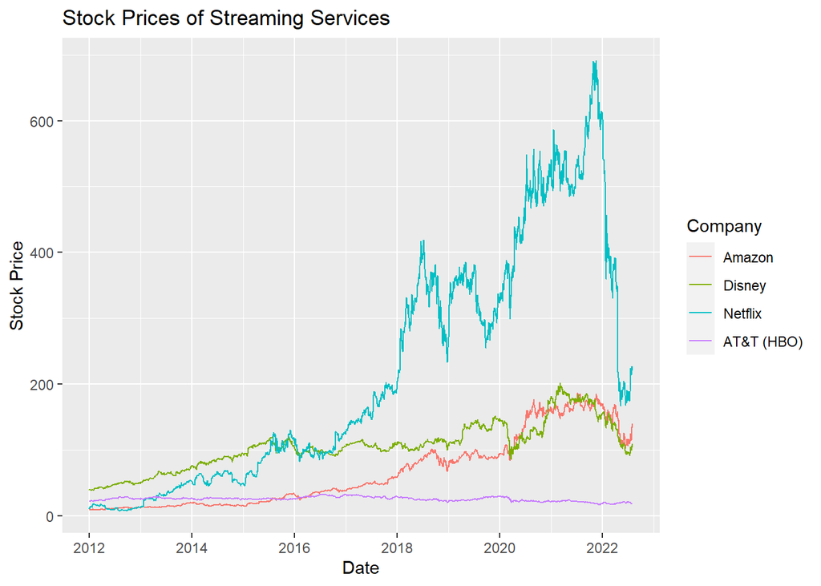

```r
# each symbol consists of rows of business days and columns of:
# stock price open, high, low, close, volume and adjusted price for that day

# merge stock data into one data frame, take close columns from each stock and combine with date
stocks <- data.frame("Netflix" = NFLX$NFLX.Close, "HBO" = T$T.Close, "Disney"=DIS$DIS.Close, "Amazon" = AMZN$AMZN.Close, "Date" = as.Date(row.names(as.data.frame(NFLX))))

# now lets just filter from 2012 to see the last 10 years
dated_stocks <- filter(stocks, Date >= "2012-01-01")

# Reshaping the data frame so one column contains the type of stock
# gather by stocks, with close price as values, bring date to first column
graphable <- dated_stocks %>% gather(key = "stock", value = "value", -Date)

# Graphing the stock prices, Date on x axis, value on y, colored by difference stock
graphable %>% ggplot() + geom_line(aes(x = Date, y= value, color = stock)) +
  scale_color_discrete(name = "Company", labels = c("Amazon", "Disney", "Netflix", "AT&T (HBO)")) +
  labs(title = "Stock Prices of Streaming Services", y = "Stock Price")
```

Netflix clearly has clearly grown more for a few years but has since recently dropped to near where the other companies prices are at.

Now the last library we will load is the `gtrendsR` library. This is the Google Trend library that allows us to find the popularity of Google search terms over time. Using this data, we can visualize the relative popularity of the shows and approximate their release dates.

```r
library(gtrendsR)

# Let create the trends dataframe where we look at the mandalorian, stranger things, game of thrones and the boys tv shows
trends <- gtrends(
  keyword=c("mandalorian", "stranger things", "game of thrones", "the boys"),
  time = "2012-01-01 2022-08-03")

# now we make the trends over time dataframe, load hits as numeric and replace blanks with 0
trends_over_time <- trends$interest_over_time
trends_over_time <- trends_over_time %>% mutate(hits = as.numeric(hits))
```

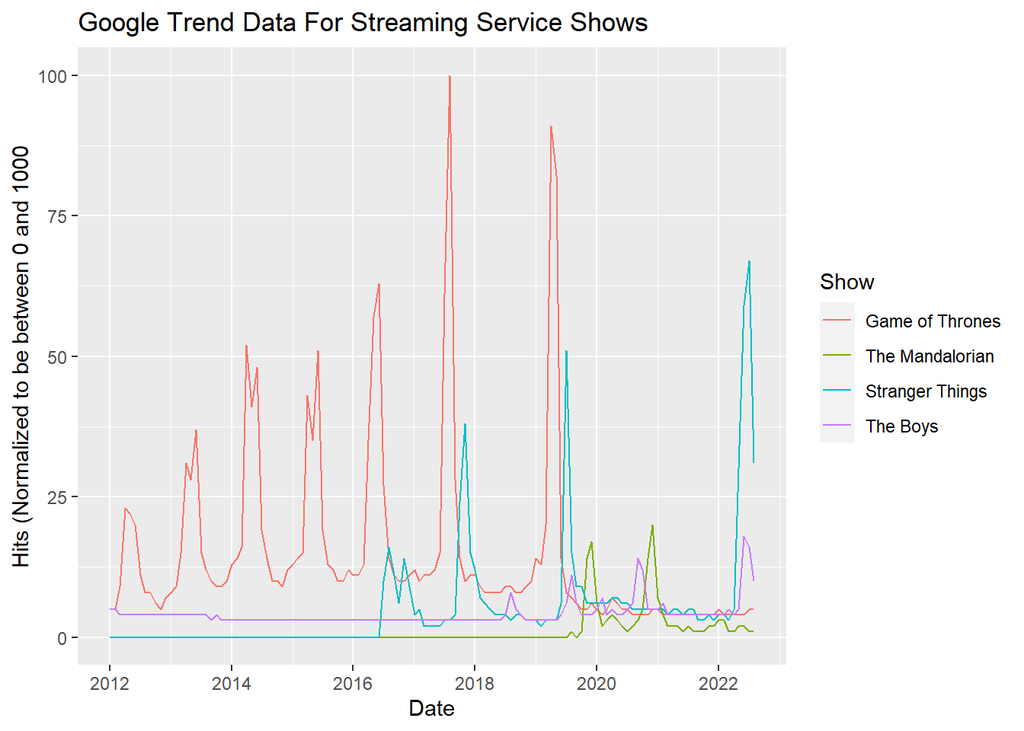

```r
trends_over_time <- trends_over_time %>% replace_na(list(hits = 0))

# plot the trends of hits over time with the shows as different colors.
trends_over_time %>% ggplot() + geom_line(aes(date, hits, color = keyword)) +
  scale_color_discrete(name = "Show", labels = c("Game of Thrones", "The Mandalorian", "Stranger Things", "The Boys" )) +
  labs(title = "Google Trend Data For Streaming Service Shows", y = "Hits (Normalized to be between 0 and 1000", x = "Date")
```

Game of Thrones was clearly tremendously popular a while ago with Stranger Things now being a new favorite.

### The Trends

Before we compare this trend data to the stock data, let’s see if there are other trends we can visualize. By adding `geo = "US"` we were able to get trend data on a state level by looking at the `interest_by_region` data frame. We also used the `maps` library to help create maps of the United States.

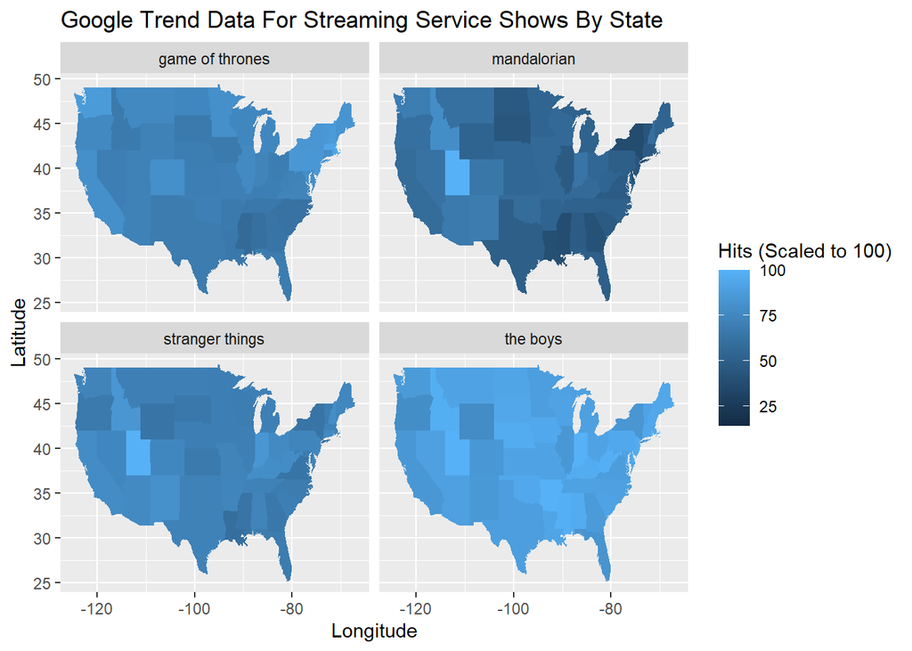

```r
library(maps)
# Getting trends by state:
# set region trends dataframe as dataframe of shows along with US as geography and time over last 10 years
# set states as dataframe of hits by location by show
# lower casing the name of the state to match with the map data
region_trends <-  gtrends(keyword=c("mandalorian", "stranger things", "game of thrones", "the boys"),
  geo = "US" ,
  time = "2012-01-01 2022-08-03")
states <- region_trends$interest_by_region
states <- states %>% mutate(location = tolower(location))

# Getting the map data
states_map <- map_data("state")

# Plotting the map
states %>% ggplot(aes(map_id = location)) +
  geom_map(aes(fill = hits), map = states_map) +
  expand_limits(x = states_map$long, y = states_map$lat) +
  facet_wrap(~ keyword, nrow = 2) +
  labs(title = "Google Trend Data For Streaming Service Shows By State", x = "Longitude", y = "Latitude") +
  scale_fill_continuous(name = "Hits (Scaled to 100)")
```

Insights like this may help companies get a better understanding of who is watching their shows. For example, Utah residents seem to love Stranger Things and The Mandalorian. Perhaps companies could look into advertising more science fiction shows in that area.

### Combining Trend with Stock Data

Using Google Trend data, let’s each company’s stock price along with the popularity of their respective shows.Even though many of the shows did not exist 10 years ago, we still look at the stock over the 10 years to get a larger view of the overall trend.

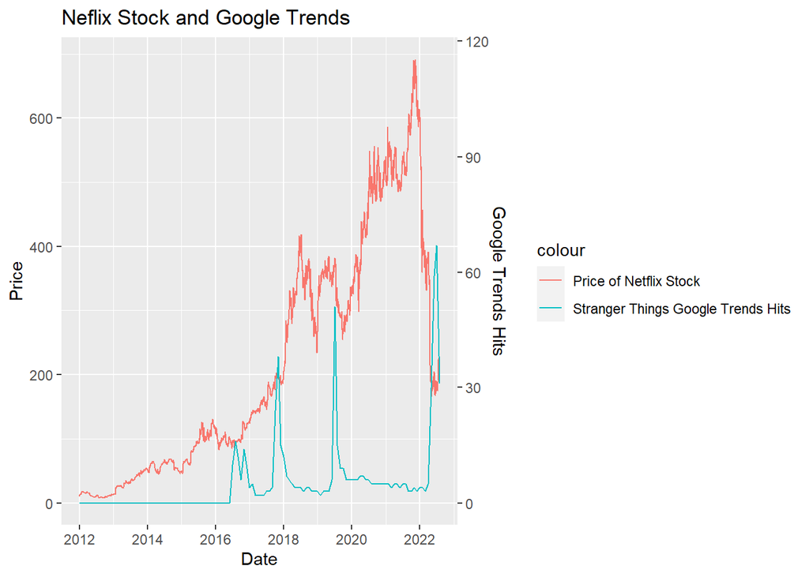

```r
#Plotting stock and trends on the same graph for Netflix and Stranger Things. Note that we adjust the scale of the Trends axis
ggplot() + geom_line(dated_stocks, mapping = aes(x = Date, y= NFLX.Close, color = "Price of Netflix Stock")) +
  geom_line(filter(trends_over_time, keyword == "stranger things"), mapping = aes(as.Date(date), hits*6, color = "Stranger Things Google Trends Hits")) +
  scale_y_continuous(name = "Price", sec.axis = sec_axis(~./6, name="Google Trends Hits")) +
  labs(title = "Neflix Stock and Google Trends")
```

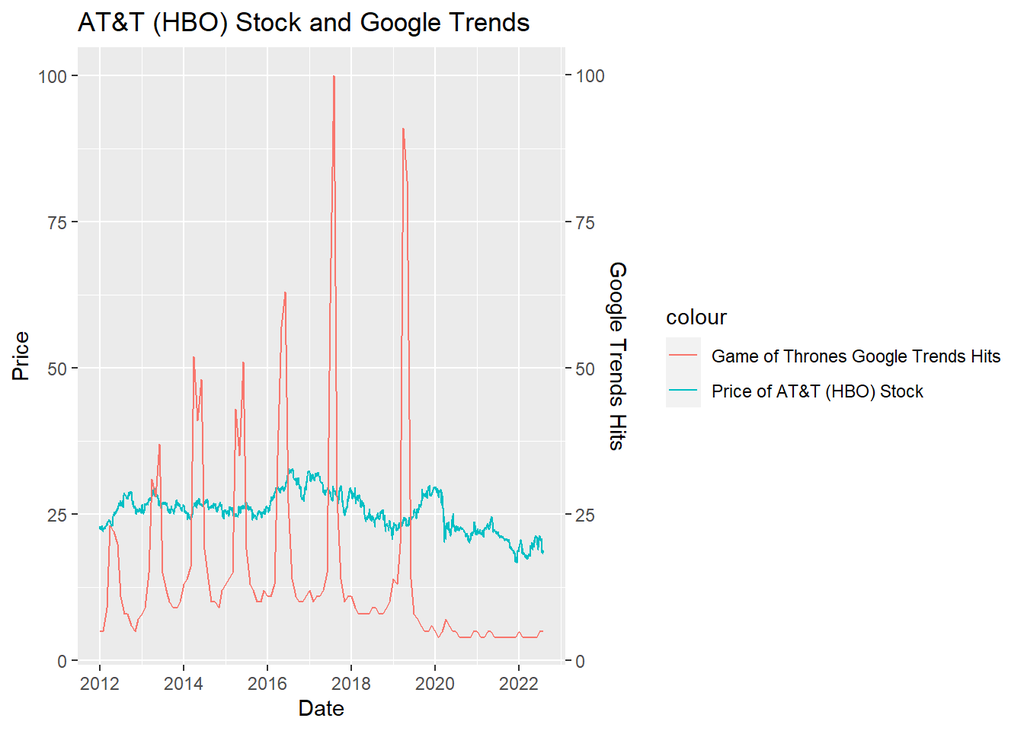

```r
# Plotting AT&T (HBO) Stock and Google Trends for Game of Thrones on the same graph
ggplot() + geom_line(dated_stocks, mapping = aes(x = Date, y= T.Close, color = "Price of AT&T (HBO) Stock")) +
  geom_line(filter(trends_over_time, keyword == "game of thrones"), mapping = aes(as.Date(date), hits, color = "Game of Thrones Google Trends Hits")) +
  scale_y_continuous(name = "Price", sec.axis = sec_axis(~., name="Google Trends Hits")) +
  labs(title = "AT&T (HBO) Stock and Google Trends")
```

[figure not shown]

```r
# Plotting Disney Stock and Google Trends for The Mandalorian on the same graph
ggplot() + geom_line(dated_stocks, mapping = aes(x = Date, y= T.Close, color = "Price of Disney Stock")) +
  geom_line(filter(trends_over_time, keyword == "mandalorian"), mapping = aes(as.Date(date), hits, color = "The Mandalorian Google Trends Hits")) +
  scale_y_continuous(name = "Price", sec.axis = sec_axis(~., name="Google Trends Hits")) +
  labs(title = "Disney Stock and Google Trends")
```

[figure not shown]

```r
# Plotting Amazon Stock and Google Trends for The Boys on the same graph
ggplot() + geom_line(dated_stocks, mapping = aes(x = Date, y= T.Close, color = "Price of Amazon Stock")) +
  geom_line(filter(trends_over_time, keyword == "the boys"), mapping = aes(as.Date(date), hits, color = "The Boys Google Trends Hits")) +
  scale_y_continuous(name = "Price", sec.axis = sec_axis(~., name="Google Trends Hits")) +
  labs(title = "Amazon Stock and Google Trends")
```

### Checking for Linear Regression

Finally, let’s see if there was a correlation between any of these services. Perhaps if Netflix’s stock rises, AT&T’s stock will fall. We created a plot with Netflix’s stock on the x axis and Disney’s stock on the y axis. Note that we only used data points starting from September 2019 since that was the month of Disney Plus’ launch.

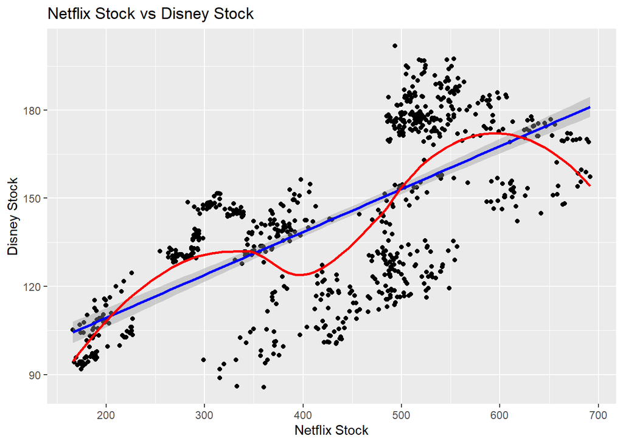

```r
# Filtering the stock data with dates after 2019
# the data frame contains close data of all 4 companies
stocks_since_disney_plus <- stocks %>% filter(Date > as.Date("2019-09-01"))

# Plotting Netflix stock vs Disney Stock's line of best fit and adding a LOESS smoother
# LOESS is Locally estimated scatter plot smoothing, is a moving average of the regression.
# it helps us find the actual moving average and compare to our estimated line
stocks_since_disney_plus %>% ggplot(aes(x = NFLX.Close, y = DIS.Close)) +
  geom_point() +
  geom_smooth(method = "lm", color = "blue") +
  geom_smooth(se = FALSE, color = "red") +
  labs(title = "Netflix Stock vs Disney Stock", x = "Netflix Stock", y = "Disney Stock")
```

The relationship looks somewhat linear but it’s hard to say to what extent. This is unsurprising — it would have been pretty amazing if the stock prices of two companies were so closely correlated. Perhaps a multiple linear regression model or a model that considers more factors would be more effective at predicting stock prices.

### Regression Analysis

```r
# create model that analyzes the linear regression of Netflix stock and Disney stock closes since 2019
model = lm(NFLX.Close ~ DIS.Close, data = stocks_since_disney_plus)

# summarize the model to analyze results
summary(model)
```

```
##
## Call:
## lm(formula = NFLX.Close ~ DIS.Close, data = stocks_since_disney_plus)
##
## Residuals:
##     Min      1Q  Median      3Q     Max
## -168.79  -72.75  -13.90   81.59  215.55
##
## Coefficients:
##             Estimate Std. Error t value Pr(>|t|)
## (Intercept)   9.9364    18.3978    0.54    0.589
## DIS.Close     2.9718     0.1252   23.73   <2e-16 ***
## ---
## Signif. codes:  0 '***' 0.001 '**' 0.01 '*' 0.05 '.' 0.1 ' ' 1
##
## Residual standard error: 96.71 on 734 degrees of freedom
## Multiple R-squared:  0.4341, Adjusted R-squared:  0.4334
## F-statistic: 563.1 on 1 and 734 DF,  p-value: < 2.2e-16
```

```r
#RSE analysis
sigma(model)
```

```
## [1] 96.71418
```

```r
avg_rse <- sigma(model)/mean(stocks_since_disney_plus$NFLX.Close)
avg_rse
```

```
## [1] 0.2206871
```

#### RSE and R^2

Finally let’s look at the goodness of fit of our line by looking at the Residual Standard Error and the R-Squared.

The Residual Standard Error is the estimate of standard deviation of error between each point and the line of best fit, usually the lower this amount, the better the line of fit.

R squared: can tell us how much variation of a dependent variable is caused by the independent variable. 100% means all movement is explained by independent, higher the number, the higher the correlation between the 2 variables.

## Conclusion

In this project we were able to compare and contrast different methods for evaluating the success of a streaming service. Google Trends helped identify when a streaming platform has released a new show. Stock prices are a good indicator of the value of a company. But ultimately, these two data sets seem to be too general to reveal any new insights when used together. However, we began to uncover some interesting information when looking further into specific data sets. When we looked at specific region data we were able to get a better sense of different demographics and their interests.